# Spatial Analytics Assignment 7: Autocorrelation

Rebecca Folmer Schade

marts 28, 2021

## Introduction

In this assignment, I will be answering the following question:  
Is the population of single women in Denmark in 2020 spatially correlated? What is the correlation and how significant is the trend?

## Solution

### Loading packages

```r
pacman::p_load(pacman, tidyverse, raster, sf, rgeos, spdep)
# > Pacman has p_load, tidiverse has awesome data manipulation powers, raster is for loading spatial data, sf for working with it, rgeos helps transforming it, spdep for defining neighbors
```

### Loadind data

```r
# Loading attribute data
attribute <- read_csv("data/DKStatData_CivilStatus2015_2020 - Sheet1.csv")
# Loading spatial data
municipalities <- readRDS("data/gadm36_DNK_2_sp.rds")
# > belatedly, I have realized that this could have been done using getData(). This would have spared me all the trouble of rooting around in the class GitHub repository for the dataset, but it is what it is.
```

### Exploring (and transforming) the data

```r
#===> Spatial data
# The 'municipalities' object has the class 'sp' (also called 'SpatialPolygonsDataFrame') as can be seen in the code below.
class(municipalities)
```

```
## [1] "SpatialPolygonsDataFrame"
## attr(,"package")
## [1] "sp"
```

```r
# These are a bit more cumbersome to deal with, as they are coded as lists of lists. Therefore, I will transform it into a Simple Features (or 'sf') object.
mun_sf <- st_as_sf(municipalities)
# As you can see, the class has now changed!
class(mun_sf)
```

```
## [1] "sf"         "data.frame"
```

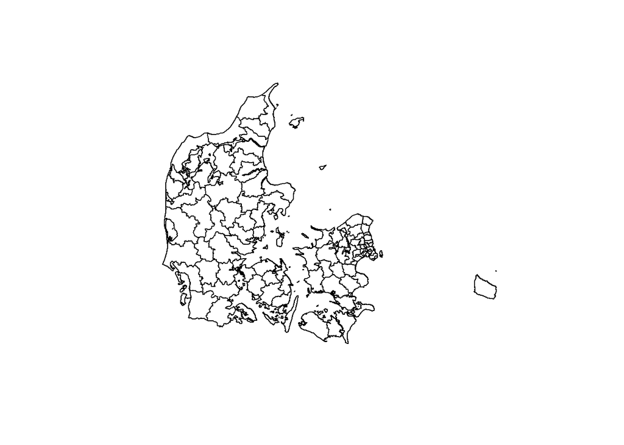

```r
# Changing projection to the UTM used for Denmark
mun <- st_transform(mun_sf, crs = 32632)
# Plotting to sanity check
plot(st_geometry(mun))
```

```r
# > It looks fine

#===> Attribute data
head(attribute)
```

```
## # A tibble: 6 x 9
##   Status Sex   Region            Y2020K1 Y2019K1 Y2018K1 Y2017K1 Y2016K1 Y2015K1
##   <chr>  <chr> <chr>               <dbl>   <dbl>   <dbl>   <dbl>   <dbl>   <dbl>
## 1 Ugift  Mænd  Region Hovedstad~  505534  501661  496990  491682  484732  476046
## 2 Ugift  Mænd  København          209722  206625  202884  198967  195110  190676
## 3 Ugift  Mænd  Frederiksberg       30279   30065   30220   30540   30171   29589
## 4 Ugift  Mænd  Dragør               3097    3012    3009    3001    2937    2881
## 5 Ugift  Mænd  Tårnby              10639   10564   10576   10544   10416   10294
## 6 Ugift  Mænd  Albertslund          7390    7429    7397    7458    7453    7375
```

```r
unique(attribute$Status)
```

```
## [1] "Ugift"          "Gift/separeret" "Enke/enkemand"  "Fraskilt"
```

```r
unique(attribute$Sex)
```

```
## [1] "Mænd"    "Kvinder"
```

As can be seen here, this dataset does not contain data on whether or not each citizen is 'single', rather, it contains data on civil status (marrried/separated, unmarried, divorced, widow/widower). It is important to note for the remainder of this analysis that none of these categories can be used to infer citezens' relationship statuses. In the categories "unmarried", "divorced", and "widow/widower", this is because a citizen not being married currently does not guarrantee that said citizen is not in a relationship. In the case of the "married/separated" category, this is because one could argue that being separated should count as being single.

```r
#===> While I know from the lecture that there is a discrepency between the names of the municipalities in the attribute dataset and the one containing the geometries of the municipalities, I decided that it would be a learning oppertunity to see if I could identify these differences myself.

# Making lists of the names of the municipalities in the two datasets
names_attr <- sort(unique(attribute$Region))
names_mun <- sort(mun$NAME_2)

# Checking if there are any differences
names_attr == names_mun
```

```
##   [1]  TRUE  TRUE  TRUE  TRUE  TRUE  TRUE  TRUE  TRUE  TRUE  TRUE  TRUE  TRUE
##  [13]  TRUE  TRUE  TRUE  TRUE  TRUE  TRUE  TRUE  TRUE  TRUE  TRUE  TRUE  TRUE
##  [25]  TRUE  TRUE  TRUE  TRUE  TRUE  TRUE  TRUE  TRUE  TRUE  TRUE  TRUE  TRUE
##  [37]  TRUE  TRUE  TRUE  TRUE FALSE  TRUE  TRUE  TRUE  TRUE  TRUE  TRUE  TRUE
##  [49]  TRUE  TRUE  TRUE  TRUE  TRUE  TRUE  TRUE  TRUE  TRUE  TRUE  TRUE  TRUE
##  [61]  TRUE  TRUE  TRUE  TRUE  TRUE  TRUE  TRUE  TRUE FALSE FALSE FALSE FALSE
##  [73] FALSE FALSE FALSE FALSE FALSE FALSE FALSE FALSE FALSE FALSE FALSE FALSE
##  [85] FALSE FALSE FALSE FALSE FALSE FALSE FALSE FALSE FALSE FALSE FALSE FALSE
##  [97] FALSE FALSE FALSE FALSE FALSE FALSE FALSE FALSE
```

```r
# > There are differences
# Do I perhaps get this output because there is an unequal number of names in the two datasets
length(names_attr)
```

```
## [1] 104
```

```r
length(names_mun)
```

```
## [1] 99
```

```r
# > Yes!
# Finding the names that do not appear in both datasets
setdiff(names_attr,names_mun)
```

```
## [1] "Høje-Taastrup"      "Region Hovedstaden" "Region Midtjylland"
## [4] "Region Nordjylland" "Region Sjælland"    "Region Syddanmark"
## [7] "Vesthimmerlands"    "Aarhus"
```

```r
setdiff(names_mun,names_attr)
```

```
## [1] "Høje Taastrup"  "Vesthimmerland" "Århus"
```

```r
# > From this we can see that the diferences between datasets are a product of alternative spellings, as well as the attrubute dataset containing data at the level of regions as well as municipalities.
# Fining which rows contain the problematic names
which(!mun$NAME_2 %in% names_attr)
```

```
## [1] 21 31 60
```

```r
# Might it be fitting here to filter out the regions?

# Straightening the names
mun$NAME_2[21] <- "Høje-Taastrup"
mun$NAME_2[31] <- "Aarhus"
mun$NAME_2[60] <- "Vesthimmerlands"
```

### Joining data

```r
#===> Getting rid of unnecesary information
# Isolating year 2020
useful_attribute <- attribute %>% dplyr::select(Status, Sex, Region, Y2020K1)
# Getting rid of all the men
women <- useful_attribute %>% filter(Sex == "Kvinder")
# Getting rid of the regional level data
regions <- setdiff(sort(unique(attribute$Region)),sort(mun$NAME_2))
women <- women %>% filter(!Region %in% regions)
# Removing NAs
women <- women[complete.cases(women),]
# How does it look now?
head(women)
```

```
## # A tibble: 6 x 4
##   Status Sex     Region        Y2020K1
##   <chr>  <chr>   <chr>           <dbl>
## 1 Ugift  Kvinder København      202790
## 2 Ugift  Kvinder Frederiksberg   30502
## 3 Ugift  Kvinder Dragør           2747
## 4 Ugift  Kvinder Tårnby           9308
## 5 Ugift  Kvinder Albertslund      6405
## 6 Ugift  Kvinder Ballerup        10482
```

```r
# Calculating total nr. of women by regions
women <- women %>% group_by(Region) %>% mutate(total = sum(Y2020K1))

# Calculating percenteges
women <- women %>% group_by(Region) %>% mutate(percent = Y2020K1/total*100)

# We only want percenteges of unmarried women, so let's get rid of the married women
unmarried <- women %>% filter(Status != "Gift/separeret")
unique(unmarried$Status)
```

```
## [1] "Ugift"         "Enke/enkemand" "Fraskilt"
```

```r
# Getting rid of columns with redundant information
unmarried <- unmarried %>% dplyr::select(Region, total, Y2020K1, percent)
# Renaming columns for transperency
colnames(unmarried)[2:4] <- c("Total_women", "Number_unmarried", "Percent_unmarried")

# Let's take a look at the new dataset
head(unmarried)
```

```
## # A tibble: 6 x 4
## # Groups:   Region [6]
##   Region        Total_women Number_unmarried Percent_unmarried
##   <chr>               <dbl>            <dbl>             <dbl>
## 1 København          320286           202790              63.3
## 2 Frederiksberg       54785            30502              55.7
## 3 Dragør               7372             2747              37.3
## 4 Tårnby              21697             9308              42.9
## 5 Albertslund         13940             6405              45.9
## 6 Ballerup            24831            10482              42.2
```

```r
#===> Merging with spatial data
civil_status <- mun %>% dplyr::select(NAME_2) %>% merge(unmarried, by.x = "NAME_2",by.y ="Region")
head(civil_status)
```

```
## Simple feature collection with 6 features and 4 fields
## geometry type:  MULTIPOLYGON
## dimension:      XY
## bbox:           xmin: 700891 ymin: 6171296 xmax: 714402 ymax: 6200000
## projected CRS:  WGS 84 / UTM zone 32N
##        NAME_2 Total_women Number_unmarried Percent_unmarried
## 1 Albertslund       13940             6405         45.946915
## 2 Albertslund       13940             1655         11.872310
## 3 Albertslund       13940              860          6.169297
## 4     Allerød       13093             5083         38.822271
## 5     Allerød       13093             1160          8.859696
## 6     Allerød       13093              917          7.003742
##                         geometry
## 1 MULTIPOLYGON (((712057 6173...
## 2 MULTIPOLYGON (((712057 6173...
## 3 MULTIPOLYGON (((712057 6173...
## 4 MULTIPOLYGON (((700891 6191...
## 5 MULTIPOLYGON (((700891 6191...
## 6 MULTIPOLYGON (((700891 6191...
```

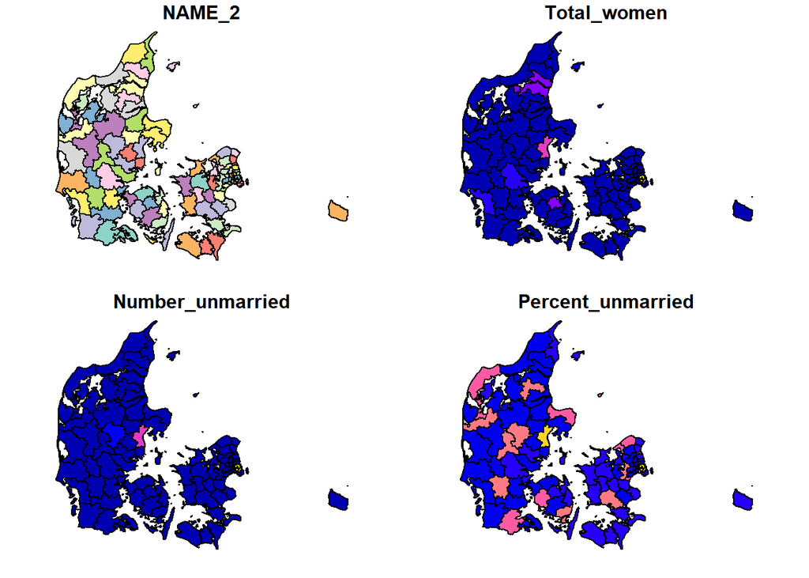

```r
# Plotting the data for a sanity check
plot(civil_status)
```

```r
# This does not look perticularily clustered.
```

### Defining neighboors

```r
# creating the nb object with the nearest neigbhors
nb <- poly2nb(civil_status$geometry)
nb
```

```
## Neighbour list object:
## Number of regions: 297
## Number of nonzero links: 3960
## Percentage nonzero weights: 4.489338
## Average number of links: 13.33333
```

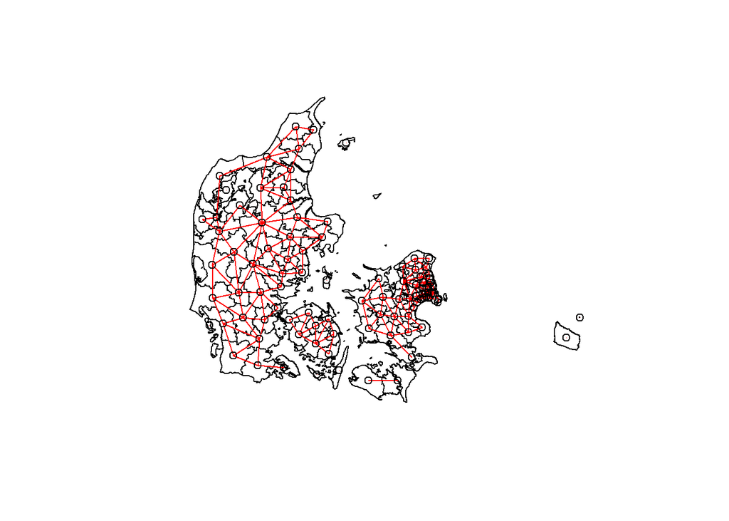

```r
# Getting center points of each municipality
mun_centers <- st_coordinates(st_centroid(civil_status$geometry))

# Showing the connections
plot(civil_status$geometry)
plot(nb, mun_centers, col = "red", add = TRUE)
```

### Computing the test statistic

```r
# Computing Moran's I using montecarlo simulations
moran.mc(civil_status$Percent_unmarried, nb2listw(nb, style = "W", zero.policy = TRUE), zero.policy = TRUE, nsim = 999)
```

```
##
##  Monte-Carlo simulation of Moran I
##
## data:  civil_status$Percent_unmarried
## weights: nb2listw(nb, style = "W", zero.policy = TRUE)
## number of simulations + 1: 1000
##
## statistic = -0.08718, observed rank = 1, p-value = 0.999
## alternative hypothesis: greater
```

## Conclution

As the p-value is over .05, it does not seem like women who are not currently married are spatially correlated. This is, however, a poor answer to the original question (i.e., are single women spatially correlated). But as civil status is insufficient to infer relationaship status, this is the best answer I could get in this assignment.